# **Curso**

## *12.4 Densidade*

A densidade é outra forma visual de verificar a frequência dos dados.

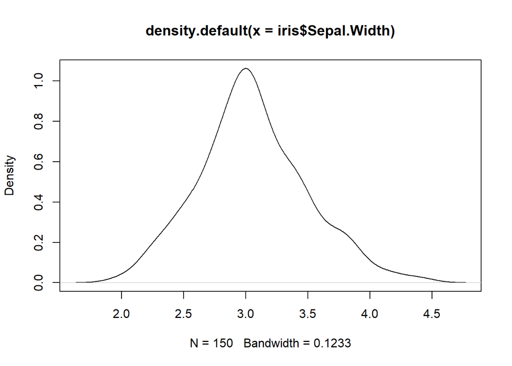

```r
densidade = density(iris$Sepal.Width) #Avaliando a densidade e atribuindo à variável densidade
plot(densidade) #Gerando um gráfico de densidade
```

## *12.5 Sobrepondo Gráficos*

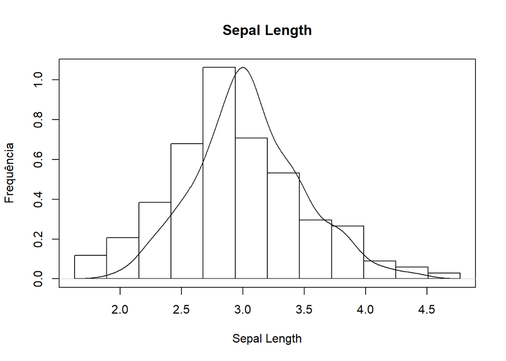

```r
hist(iris$Sepal.Width, xlab = NULL, ylab = NULL, main = NULL, xaxt= "n", yaxt="n") #Criando um histograma, sem eixos, sem título e sem valores ("n" nos xaxt e yaxt)
par(new = TRUE) #New = True significa um novo gráfico que ficará sobreposto
densidade = density(iris$Sepal.Width) #Avaliando a densidade e atribuindo à variável densidade
plot(densidade, xlab = "Sepal Length", ylab = "Frequência", main = "Sepal Length") #Atribuindo nomes aos eixos, ao título do gráfico e alterando a cor
```

## *12.6 Boxplot*

O gráfico de boxplot é claro conquanto à apresentação de um resumo estatístico dos dados. Vamos primeiramente visualizar um boxplot:

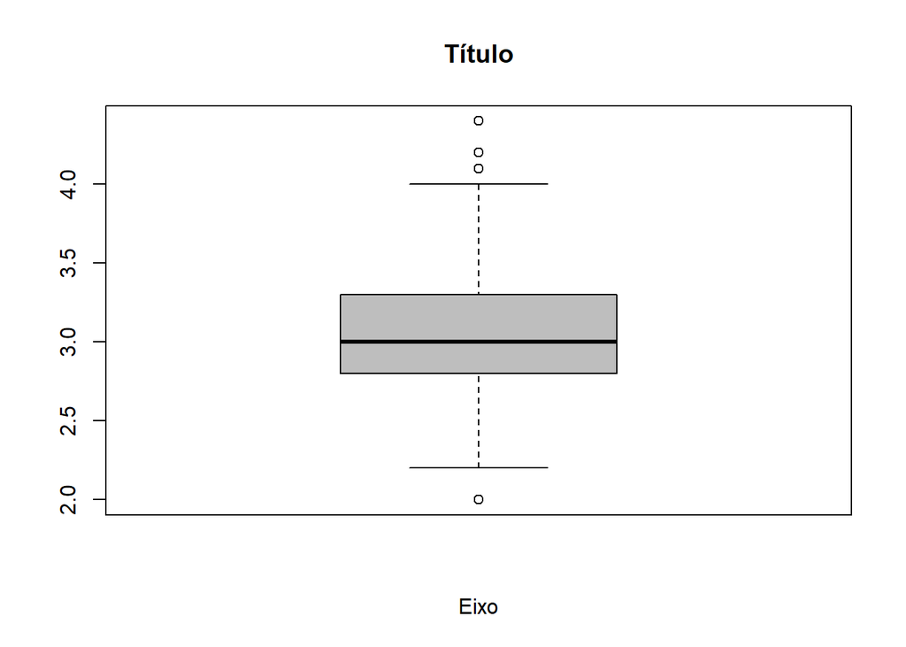

```r
boxplot(iris$Sepal.Width, main = "Título", xlab = "Eixo", col = "gray")
```

### *12.6.1 As caractetísticas do Boxplot*

Nele visualizamos uma caixa que demonstra a alocação dos dados. A linha em destaque demonstra o ponto onde há a mediana dos dados. O topo da caixa se refere ao terceiro quartil, e o vale da caixa demonstra o primeiro quartil. O topo do gráfico demonstra o limite superior: calculamos ele, basicamente, multiplicando a amplitude interquartil (Q3 - Q1) por 1,5 e acrescentamos ao Q3. O mesmo processo se repete ao limite inferior, contando que devemos subtrair a amplitude (multiplicada por 1,5) pelo Q1. Os pontos que estão acima ou abaixo desses limites são chamados de **outliers**. Mas o que são *outliers*? Há como defini-lo como uma observação distante do padrão observado, sendo que pode ocorrer por: Entrada de dados errados no dataset, erros de experimento, um evento intencional ou até mesmo uma observação natural. Podemos encontrar um resumo básico utilizando a função `boxplot.stats()`

```r
boxplot.stats(iris$Sepal.Width)
```

```
## $stats
## [1] 2.2 2.8 3.0 3.3 4.0
##
## $n
## [1] 150
##
## $conf
## [1] 2.935497 3.064503
##
## $out
## [1] 4.4 4.1 4.2 2.0
```

## *12.7 Gráfico de Barras*

### *12.7.1 Analisando*

Vamos analisar o dataset InsectSprays (nativo no R) e verificar suas varíaveis

```r
dplyr::glimpse(InsectSprays)
```

```
## Rows: 72
## Columns: 2
## $ count <dbl> 10, 7, 20, 14, 14, 12, 10, 23, 17, 20, 14, 13, 11, 17, 21, 11...
## $ spray <fct> A, A, A, A, A, A, A, A, A, A, A, A, B, B, B, B, B, B, B, B, B...
```

```r
agregar = aggregate(count ~ spray, data = InsectSprays, sum)
#Colocamos primeiramente a variável que será agregada
#Separamos por um ~ e colocamos a coluna dos fatores
#Declaramos de onde os dados estão vindo
#Utilizamos a função "sum" para agregação (dito que necessitamos somar os valores)
agregar
```

```
##   spray count
## 1     A   174
## 2     B   184
## 3     C    25
## 4     D    59
## 5     E    42
## 6     F   200
```

### *12.7.2 Gerando o Gráfico*

Com o dataframe agregado, podemos criar um gráfico de barras com a coluna agregada (count).

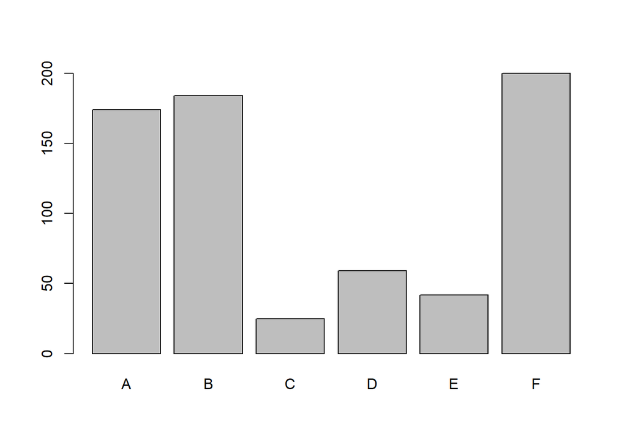

```r
barplot(agregar$count, names.arg = agregar$spray) #names.arg estamos atribuindo nomes ao eixo X.
```

## *12.8 Dividindo a tela para alocação de vários gráficos*

Geralmente, para construção de um relatório necessitamos alocar vários gráficos em uma tela só. É possível fazer isso utilizando a função `split.screen()`. Nela, passamos o parâmetro *figs = c(n,m)*, sendo que: n = “número de linhas” e m = “número de colunas”. Para acessar as telas, utilizamos a função `screen()`. Após acessar todas as telas, **precisamos fechar a seção** com a função `close.screen()`.

```r
split.screen(figs = c(2,2)) #figs = c(2,2), ou seja, duas linhas e duas colunas
```

```
## [1] 1 2 3 4
```

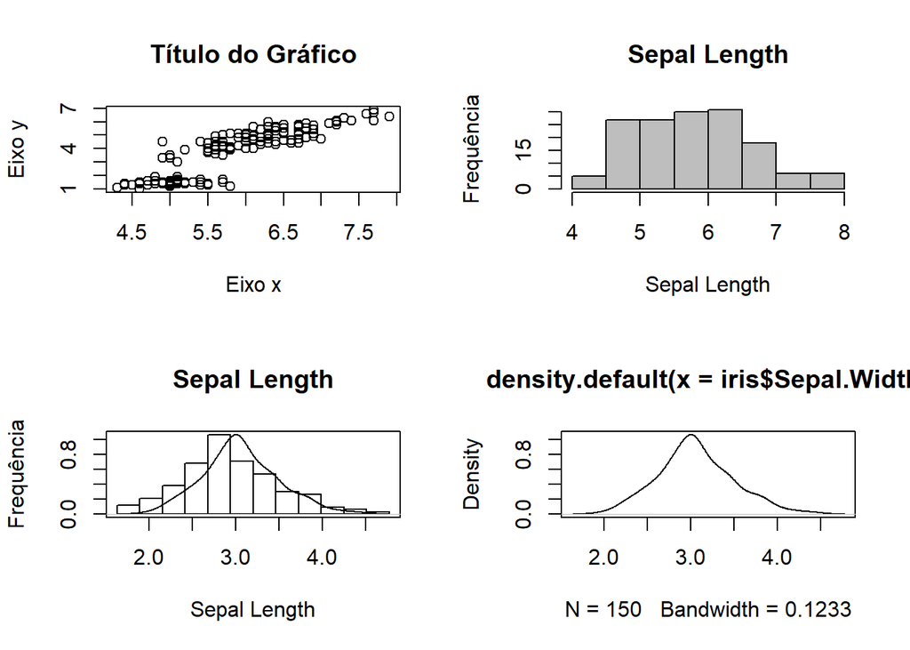

```r
screen(1)
    plot(iris$Sepal.Length, iris$Petal.Length, xlab = "Eixo x", ylab = "Eixo y", main = "Título do Gráfico")
screen(2)
    hist(iris$Sepal.Length, xlab = "Sepal Length", ylab = "Frequência", main = "Sepal Length", col = "gray")
screen(3)
    hist(iris$Sepal.Width, xlab = NULL, ylab = NULL, main = NULL, xaxt= "n", yaxt="n")
    par(new = TRUE)
    densidade = density(iris$Sepal.Width)
    plot(densidade, xlab = "Sepal Length", ylab = "Frequência", main = "Sepal Length")
screen(4)
    densidade = density(iris$Sepal.Width)
    plot(densidade)
```

```r
close.screen(all = T)
```

# *13. Criando suas próprias funções*

Durante a execução de um trabalho, codificamos vários processos repetitivos e geralmente carregamos a memória do sistema. Para tais ocasiões, você pode criar suas próprias funções utilizando o comando `function()`.

```r
subtrair = function(x,y){ #Criando a função, atribuindo os parâmetros
  resultado = x - y #Criando variáveis locais
  return(resultado) #Retornando o resultado
}

subtrair(10,7) #Executando a função
```

```
## [1] 3
```

Perceba que, na criação de uma função precisamos de:

**“subtrair”**: nome da função;  
**“function()”**: = comando para criar a função;  
**“x e y”**: parâmetros da função (podemos atribuir valores padrões ou até mesmo deixar sem parâmetros);  
**“{tudo o que está dentro das chaves}”** = o corpo da função;  
**“resultado”**: é uma variável local, apenas armazenada DENTRO da função, e não no ambiente R;  
**“return”**: o que a função irá retornar.

## *13.1 Exemplo: Criando uma função para verificar se o número é par ou ímpar*

```r
verificar = function(x){

  if(x == 0){
    return("Zero não é par e nem ímpar!")}
  else if(typeof(x) != "integer"){
    return("O número não é inteiro!")
  }else if(x%%2 == 0){
    return("O número é par!")}
  else if(x%%2 == 1){
    return("O número é ímpar!")}
  }


verificar(1.2) #Número decimal
```

```
## [1] "O número não é inteiro!"
```

```r
verificar(1L) #Para criar um número inteiro, como já vimos, basta colocar o "L" do lado do número
```

```
## [1] "O número é ímpar!"
```

```r
verificar(2L)
```

```
## [1] "O número é par!"
```

```r
verificar(0)
```

```
## [1] "Zero não é par e nem ímpar!"
```

# *14. O operador Pipe*

Em um desenvolvimento, geralmente criamos várias variáveis para chegar em apenas um resultado. O processo de armazenar variáveis, dependendo do código, pode consumir exorbitantemente a memória do sistema, ocasionando lentidão, não tornando eficaz o desenvolvimento. Uma das maneiras de driblar esse obstáculo, é utilizando o pipe **%>%** (Para criar ele, basta apertar Ctrl+Shift+M).

## *14.1 Como funciona o pipe?*

O operador não é nativo do R. Para utilizá-lo, podemos instalar o pacote **magrittr**.A utilização do operador garante a diminuição do tempo de desenvolvimento, como também facilita na análise e manutenção do *script*. Basicamente, seu objetivo é usar o resultado de uma operação como entrada para outra operação. Vamos à um exemplo de como utilizar:

```r
#Calculando a raiz quadrada da soma de um vetor

x = c(20,30,40,50)
soma = sum(x)
raiz = sqrt(soma)

raiz
```

```
## [1] 11.83216
```

Observe que, neste caso precisamos definir 3 variáveis para chegar em apenas **um** resultado. Apesar ser serem poucas, em um processamento que exige várias transformações exige uma capacidade além disso!

```r
#Utilizando o operador pipe

library(magrittr) #Carregando o pacote

raiz = x %>% sum %>% sqrt
raiz
```

```
## [1] 11.83216
```

Note que: 1º: criamos a variável raiz  
2º: Colocamos o objeto a ser manipulado  
3º: Calculamos a soma  
4º: Calculamos a raiz quadrada da soma

# *15. Datas no R*

Quando precisamos de datas no R, podemos trabalhar de várias formas com elas. A forma mais simples, é criando uma data em uma string e alterando sua classe com o comando `as.Date()`. Veja a seguir:

```r
#Filtrando a data atual
data = Sys.time()
data
```

```
## [1] "2020-08-25 19:10:25 -03"
```

```r
data = "2020-08-23"
data = as.Date(data)
class(data)
```

```
## [1] "Date"
```

Entretanto, há o pacote `lubridate`. Podemos utilizar a função `dmy()` do pacote, em que, uma de suas vantagens é estruturar várias formas de escrever uma data gerando o mesmo resultado.

```r
#install.packages("lubridate") Instale o pacote, caso não tenha instalado ainda!

library(lubridate) #Carregando o pacote
dmy(14052002)
```

```
## [1] "2002-05-14"
```

```r
dmy("14052002")
```

```
## [1] "2002-05-14"
```

```r
dmy("14/05/2002")
```

```
## [1] "2002-05-14"
```

```r
dmy("14-05-2002")
```

```
## [1] "2002-05-14"
```

Perceba que, apesar de escrever a mesma data de formas diferentes, a função reconheceu a data requerida. Dito isso, podemos utilizar algumas funções dele para manipular as datas.

```r
data = dmy(14052002)

wday(data) #Dia da semana em número
```

```
## [1] 3
```

```r
wday(data, label = TRUE) #Dia da semana abreviado
```

```
## [1] ter
## Levels: dom < seg < ter < qua < qui < sex < sáb
```

```r
mday(data) #Dia do mês
```

```
## [1] 14
```

```r
month(data) #Mês
```

```
## [1] 5
```

```r
year(data) #Ano
```

```
## [1] 2002
```

```r
data + ddays(1) #Adicionando um dia
```

```
## [1] "2002-05-15"
```

```r
data + weeks(2) #Adicionando duas semanas semana
```

```
## [1] "2002-05-28"
```

```r
data + weeks(1:3) #As 3 semanas após a data
```

```
## [1] "2002-05-21" "2002-05-28" "2002-06-04"
```

```r
data + dyears(1) #Adicionando um ano
```

```
## [1] "2003-05-14 06:00:00 UTC"
```

# *16. Iterações básicas no R*

Quando temos um vetor imenso e queremos aplicar uma função para cada valor do vetor, de primeira, podemos imaginar utilizar o loop for. Observe a seguinte situação:

```r
vetor = c(1,2,3,4) #Criando um vetor

somar = function(x){ #Criando uma função simples
  return(x + 1)
  }

for(i in 1:length(vetor)){ #Somando a cada elemento do vetor o valor 1
  vetor[i] = somar(vetor[i])
}

print(vetor)
```

```
## [1] 2 3 4 5
```

Por mais básico que seja, podemos utilizar a função `map()`do pacote `purrr` para acessar cada elemento e passar uma função.

```r
#install.packages("purrr") Instale o pacote caso não tenha!
library(purrr)
```

```r
vetor = c(1,2,3,4)
map(vetor, somar) #Primeiro o vetor, segundo a função
```

```
## [[1]]
## [1] 2
##
## [[2]]
## [1] 3
##
## [[3]]
## [1] 4
##
## [[4]]
## [1] 5
```

```r
vetor = c(1,2,3,4)
map_dbl(vetor, somar)
```

```
## [1] 2 3 4 5
```

# *17. O pacote dplyr*

Semelhante à linguagem SQL, o pacote dplyr tem funções fundamentais para filtros, seleções, entre outros que tornam o limiar da manipulação. Junto ao operador pipe %>% , seu uso torna o código mais legível e amigável para o interlocutor.

## *17.1 As principais funções do pacote dplyr*

Suas principais funções são:  
**filter()** filtra linhas do dataset  
**select()** seleciona colunas do dataset  
**mutate()** cria ou altera colunas do dataset

```r
#Visualizando o dataset iris
head(iris)
```

| Sepal.Length | Sepal.Width | Petal.Length | Petal.Width | Species |
| --- | --- | --- | --- | --- |
| 5.1 | 3.5 | 1.4 | 0.2 | setosa |
| 4.9 | 3.0 | 1.4 | 0.2 | setosa |
| 4.7 | 3.2 | 1.3 | 0.2 | setosa |
| 4.6 | 3.1 | 1.5 | 0.2 | setosa |
| 5.0 | 3.6 | 1.4 | 0.2 | setosa |
| 5.4 | 3.9 | 1.7 | 0.4 | setosa |

```r
#Selecionando colunas específicas
iris %>%
  select(Sepal.Length, Petal.Length)
```

| Sepal.Length | Petal.Length |
| --- | --- |
| 5.1 | 1.4 |
| 4.9 | 1.4 |
| 4.7 | 1.3 |
| 4.6 | 1.5 |
| 5.0 | 1.4 |
| 5.4 | 1.7 |

```r
#Filtrando as colunas
iris %>%
  select(Sepal.Length, Species) %>%
  filter(Species == "setosa")
```

| Sepal.Length | Species |
| --- | --- |
| 5.1 | setosa |
| 4.9 | setosa |
| 4.7 | setosa |
| 4.6 | setosa |
| 5.0 | setosa |
| 5.4 | setosa |

```r
#Criando uma nova coluna
iris %>%
  select(Sepal.Length,Petal.Length) %>%
  mutate(Mutiply = Sepal.Length * Petal.Length)
```

| Sepal.Length | Petal.Length | Mutiply |
| --- | --- | --- |
| 5.1 | 1.4 | 7.14 |
| 4.9 | 1.4 | 6.86 |
| 4.7 | 1.3 | 6.11 |
| 4.6 | 1.5 | 6.90 |
| 5.0 | 1.4 | 7.00 |
| 5.4 | 1.7 | 9.18 |

# *18. Frequências*

Estatisticamente, analisar as frequências de um fator no nosso banco de dados pode indicar várias análises. São úteis para todo tipo, desde a identificação da moda, como até analisar distribuições.

## *18.1 Frequências absolutas no R*

Observe o dataset a seguir **(nomeei ele de “dataf” e irei utilizá-lo nos próximos tópicos)**:

| Genero | Massa | Estado |
| --- | --- | --- |
| Feminino | 75 | RS |
| Masculino | 47 | RS |
| Masculino | 71 | SP |
| Masculino | 81 | SC |
| Trans | 82 | SC |
| Masculino | 41 | RS |

```
## Rows: 50
## Columns: 3
## $ Genero <fct> Feminino, Masculino, Masculino, Masculino, Trans, Masculino,...
## $ Massa  <int> 75, 47, 71, 81, 82, 41, 54, 88, 77, 90, 45, 88, 68, 71, 88, ...
## $ Estado <fct> RS, RS, SP, SC, SC, RS, SP, SC, SC, SC, SC, SP, SP, SP, SP, ...
```

```r
#Verificando a frequência absoluta dos Sexos

#É necessário que a coluna seja um fator!

table(dataf$Genero)

#Frequência absoluta cruzada

table(dataf$Genero, dataf$Estado)
```

| Var1 | Freq |
| --- | --- |
| Feminino | 25 |
| Masculino | 17 |
| Não Identificado | 3 |
| Trans | 5 |

|  | RS | SC | SP |
| --- | --- | --- | --- |
| Feminino | 6 | 9 | 10 |
| Masculino | 5 | 9 | 3 |
| Não Identificado | 0 | 2 | 1 |
| Trans | 0 | 4 | 1 |

Percebemos que no total, temos 25 Feminino, 17 Masculino, 3 Não foram Identificados e 5 Trans. Podemos segregar esses valores por Estado, como fiz com a tabela cruzada.

## *18.2 Frequências relativas no R*

Ao invés do retorno por números absolutos, podemos retornar a probabilidade de cada fator no dataset.

```r
#Total
prop.table(table(dataf$Genero))
#Segregado por Estado em referência o valor Total
prop.table(table(dataf$Genero, dataf$Estado))
```

| Var1 | Freq |
| --- | --- |
| Feminino | 0.50 |
| Masculino | 0.34 |
| Não Identificado | 0.06 |
| Trans | 0.10 |

|  | RS | SC | SP |
| --- | --- | --- | --- |
| Feminino | 0.12 | 0.18 | 0.20 |
| Masculino | 0.10 | 0.18 | 0.06 |
| Não Identificado | 0.00 | 0.04 | 0.02 |
| Trans | 0.00 | 0.08 | 0.02 |

# *19. Amplitude de um vetor*

Podemos, por vezes necessitar de achar a amplitude de um vetor. Basicamente, é a subtração do valor máximo do valor mínimo do meu conjunto de dados. Podemos extrair separadamente esses valores, como também, podemos extraí-los juntos.

```r
maximo = max(dataf$Massa) #O valor máximo
maximo
```

```
## [1] 90
```

```r
minimo = min(dataf$Massa) #O valor mínimo
minimo
```

```
## [1] 40
```

```r
range(dataf$Massa) #Os dois valores
```

```
## [1] 40 90
```

```r
amplitude = maximo - minimo
amplitude
```

```
## [1] 50
```

# *20. Medidas de Centralidade*

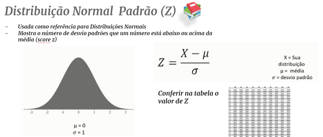

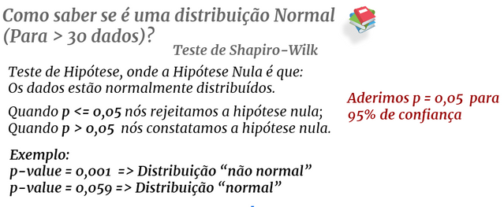

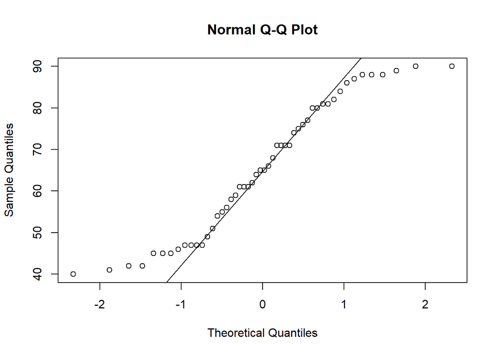

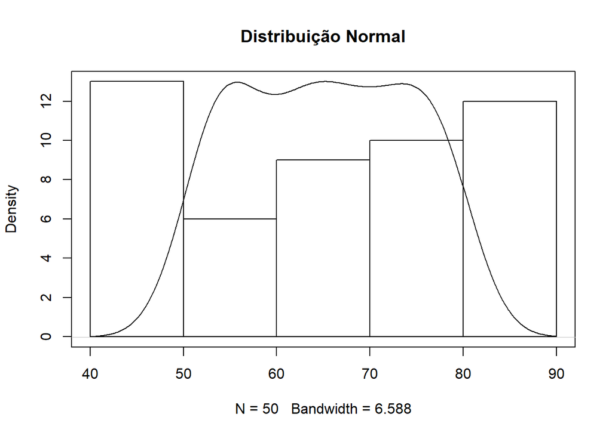

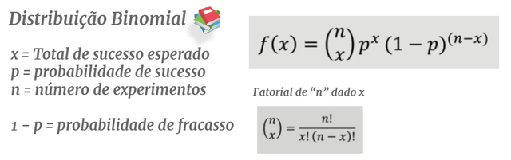

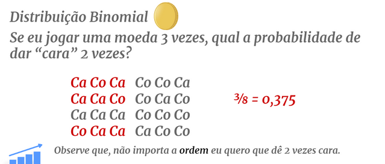

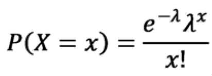

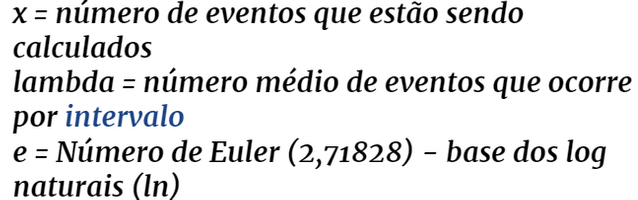